# Caso Práctico 04: Ventas Apple

Master en Data Science para Finanzas: Predicción

Ricardo A. Queralt @Cunef - V1.03

# Librerias

```r
require(forecast)
require(xts)
require(ggplot2)
```

# Leer datos

```r
# read data from CSV file
# Datos fiscales!!!!!

rawData <- read.csv2("IngresosApple.csv") #equivalente a csv2 toma delimitadores europeos. ; como separados , como dcimal
rawVentas<-rawData$Ingresos
rawDate<-seq(as.Date("2008/04/01"), as.Date("2020/10/01"), by = "quarter") #comienzo del segundo trimestre y comienzo del ultimo trimestre del an1o
tail(rawData,16)
```

|  | Trimestre | Ingresos |
| --- | --- | --- |
| 36 | Q1 2017 | 78351 |
| 37 | Q2 2017 | 52896 |
| 38 | Q3 2017 | 45408 |
| 39 | Q4 2017 | 51939 |
| 40 | Q1 2018 | 88293 |
| 41 | Q2 2018 | 61137 |
| 42 | Q3 2018 | 53265 |
| 43 | Q4 2018 | 62900 |
| 44 | Q1 2019 | 84310 |
| 45 | Q2 2019 | 58015 |

[output cut: 6 more lines]

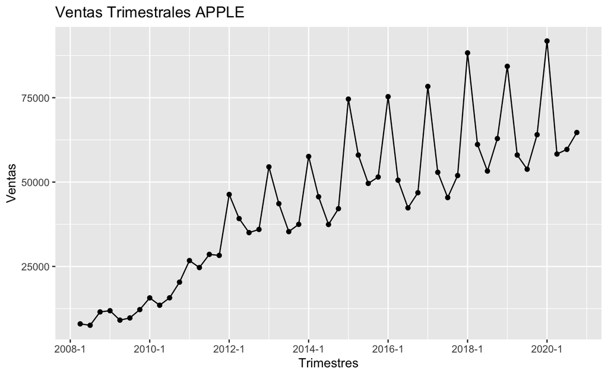

```r
##Plot Serie
autoplot(zVentas)+geom_point()+
  ylab("Ventas")+ggtitle("Ventas Trimestrales APPLE")+xlab("Trimestres")
```

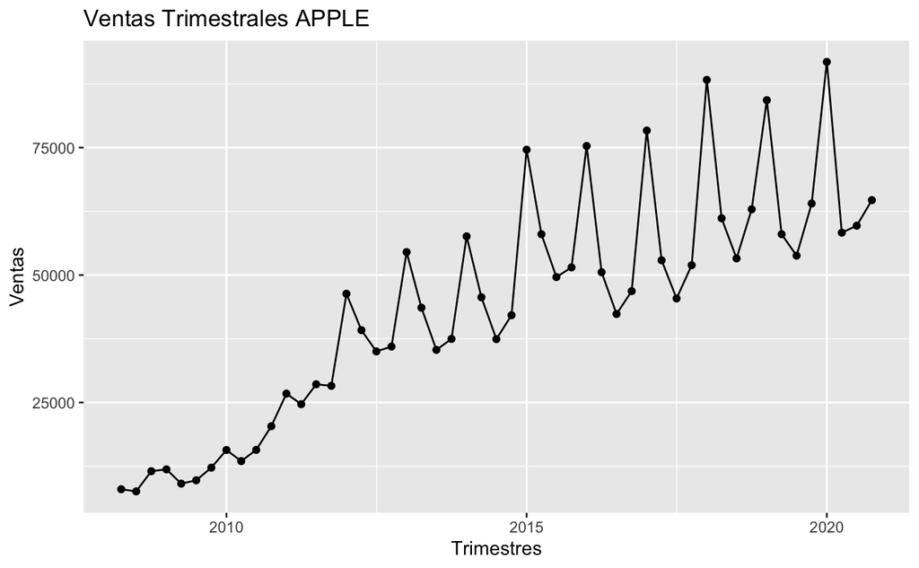

```r
df_new <- data.frame(value = coredata(xVentas$xVentas.Close),
                     time = as.Date(as.yearqtr(zoo::index(xVentas), format = "Q%q/%y")))
colnames(df_new) <- c("ventas","time")
ggplot(df_new)+geom_point(aes(x=time,y=ventas))+geom_line(aes(x=time,y=ventas))+ylab("Ventas")+ggtitle("Ventas Trimestrales APPLE")+xlab("Trimestres")
```

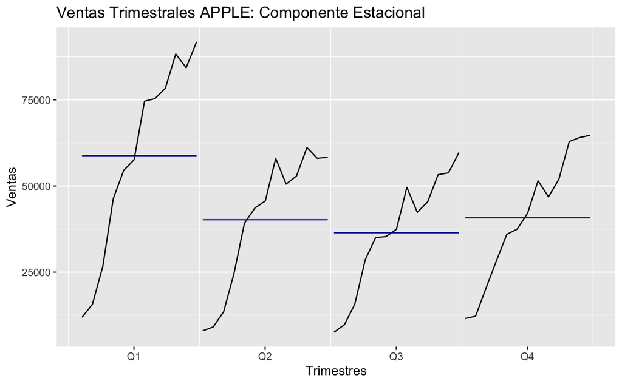

```r
#Seasonal Plot
ggmonthplot(as.ts(zVentas))+ylab("Ventas")+ggtitle("Ventas Trimestrales APPLE: Componente Estacional")+xlab("Trimestres")
```

Fundamental este grafico

En media el primer trimestre es el que mas ventas tiene. 1er trimestre fiscal corresponde al 4to trimestre del calendario.

Sirve para ver si tenemos un componente estacional.

```r
#Select number of observation to compare forecast
cOmit=16 #omito 16 datos

#Data Size
nObs=length(zVentas)

#sub_sample
oVentas <- window(zVentas,start=index(zVentas[1]),end=index(zVentas[nObs-cOmit]))

#out sample (real data to forecast performance)
pVentas <- window(zVentas,start=index(zVentas[nObs-cOmit+1]),end=index(zVentas[nObs]))
```

# ETS

```r
## Select automatic ETS
etsfit<-ets(oVentas)
#forecast model
fventas.ets=forecast(etsfit, h=16)
#Results
summary(fventas.ets)
```

```
Forecast method: ETS(M,A,M)

Model Information:
ETS(M,A,M)

Call:
 ets(y = oVentas)

  Smoothing parameters:
    alpha = 0.493
    beta  = 0.493
    gamma = 0.507

  Initial states:
    l = 7125.3462
    b = 1485.7975
    s = 1.1511 1.1163 0.8322 0.9004

  sigma:  0.1222

     AIC     AICc      BIC
703.9538 711.1538 717.9519

Error measures:
                  ME     RMSE      MAE       MPE     MAPE      MASE      ACF1
Training set -41.934 4120.155 2883.262 -0.297759 8.677434 0.4160202 0.1438481

Forecasts:
```

|  | Point Forecast | Lo 80 | Hi 80 | Lo 95 | Hi 95 |
| --- | --- | --- | --- | --- | --- |
| 2017 Q1 | 69439.83 | 58568.387 | 80311.27 | 52813.394 | 86066.26 |
| 2017 Q2 | 53347.98 | 41773.016 | 64922.95 | 35645.598 | 71050.37 |
| 2017 Q3 | 48972.04 | 33884.613 | 64059.47 | 25897.811 | 72046.27 |
| 2017 Q4 | 54176.09 | 31475.035 | 76877.14 | 19457.824 | 88894.35 |
| 2018 Q1 | 80540.07 | 32680.293 | 128399.85 | 7344.857 | 153735.28 |
| 2018 Q2 | 61619.03 | 17211.212 | 106026.85 | -6296.866 | 129534.93 |
| 2018 Q3 | 56344.41 | 7869.773 | 104819.05 | -17791.151 | 130479.97 |
| 2018 Q4 | 62103.80 | -718.363 | 124925.97 | -33974.410 | 158182.02 |
| 2019 Q1 | 92883.46 | -19130.793 | 204897.71 | -78427.555 | 264194.47 |
| 2019 Q2 | 70840.35 | -26312.837 | 167993.53 | -77742.626 | 219423.32 |

[output cut: 6 more lines]

```
Use autolayer instead of geom_forecast to add a forecast layer to your ggplot object.
```

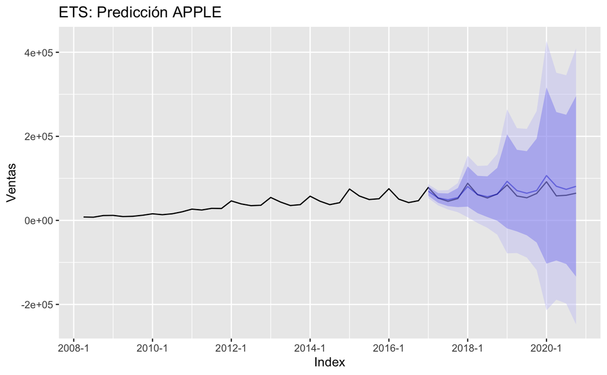

```r
#Plot
autoplot(zVentas) + geom_forecast(fventas.ets,alpha=0.4)+ggtitle("ETS: Predicción APPLE")
```

```
Use autolayer instead of geom_forecast to add a forecast layer to your ggplot object.
```

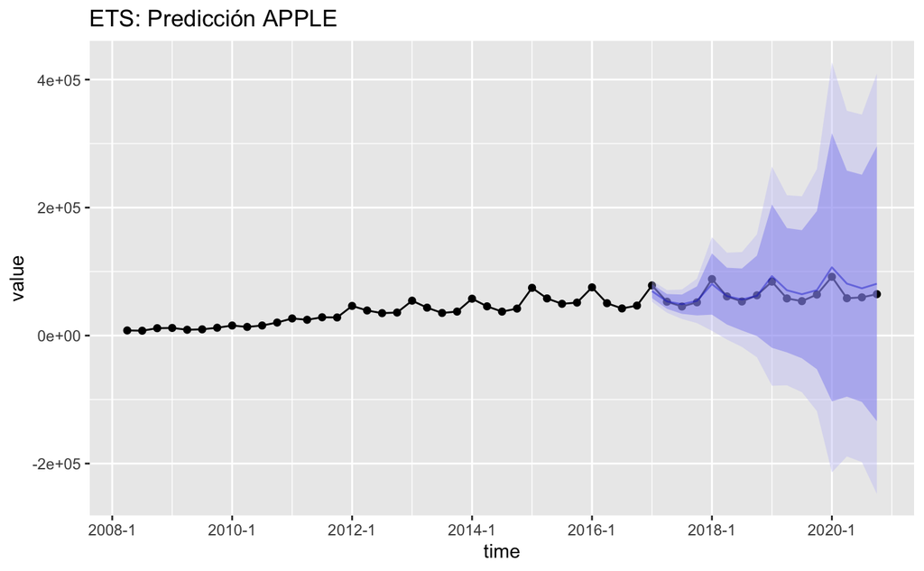

```r
df_new <- data.frame(value = as.vector(zVentas),
                     time = time(zVentas))
ggplot(df_new)+geom_point(aes(x=time,y=value))+geom_line(aes(x=time,y=value))+ geom_forecast(fventas.ets,alpha=0.4)+ggtitle("ETS: Predicción APPLE")
```

Aca se generan intervalos de confianza negativos. Esto no pasa cuando la serie esta en logaritmo. Esto nos asegura que no tengamos predicciones negativas. Eso lo veremos con el ARIMA.

La linea azul es la prediccion. En el 2017 nos dice que tenemos mas ventas a largo plazo que las que esta teniendo apple. Esto nos dice q no lo esta haciendo tan bien apple como esperabamos.

Esto son modelos de CP xq a LP nos dan mucha incertidumbre lo que nos damos cuenta por los intervalos de confianza.

```r
#Accuracy


accuracy(fventas.ets,pVentas)
```

```
                    ME      RMSE      MAE        MPE      MAPE      MASE      ACF1
Training set   -41.934  4120.155 2883.262  -0.297759  8.677434 0.4160202 0.1438481
Test set     -6222.356 10536.942 8404.893 -10.341609 13.019124 1.2127256        NA
```

Hacemos el accuracy para ver como predice el modelo en la muestra de test.

EL RMSE nos da el error en euros en media. 10000 dolares eso es muy alto. Tengamos en cuenta q son 16 trimestres.

MAE, penaliza menos que el RMSE xq este ultimo esta al cuadrado en la formula.

MAPE nos da un 13% y en la muestra 8%. En media e un error elevado. Sobre 16 trimstres no es tan grande.

```r
#Forecast out of the sample
cOmit=0

#Data Size
nObs=length(zVentas)

#sub_sample
oVentas <- window(zVentas,start=index(zVentas[1]),end=index(zVentas[nObs-cOmit]))
## Select automatic ETS
etsfit<-ets(oVentas)
#forecast model
fventas.ets=forecast(etsfit)
#Results
summary(fventas.ets)
```

```
Forecast method: ETS(M,A,M)

Model Information:
ETS(M,A,M)

Call:
 ets(y = oVentas)

  Smoothing parameters:
    alpha = 0.6005
    beta  = 0.1969
    gamma = 0.3995

  Initial states:
    l = 7148.1414
    b = 1515.1505
    s = 1.2068 1.0562 0.8258 0.9113

  sigma:  0.1083

     AIC     AICc      BIC
1054.933 1059.323 1072.320

Error measures:
                   ME     RMSE      MAE        MPE     MAPE      MASE      ACF1
Training set -143.802 4927.239 3446.958 -0.7307872 8.311221 0.5615846 0.1397828

Forecasts:
```

|  | Point Forecast | Lo 80 | Hi 80 | Lo 95 | Hi 95 |
| --- | --- | --- | --- | --- | --- |
| 2021 Q1 | 92770.65 | 79889.63 | 105651.67 | 73070.84 | 112470.47 |
| 2021 Q2 | 62971.41 | 51805.42 | 74137.40 | 45894.51 | 80048.32 |
| 2021 Q3 | 61778.20 | 47952.75 | 75603.66 | 40634.00 | 82922.41 |
| 2021 Q4 | 67254.84 | 48655.03 | 85854.66 | 38808.88 | 95700.81 |
| 2022 Q1 | 96998.97 | 61279.04 | 132718.90 | 42370.05 | 151627.89 |
| 2022 Q2 | 65817.74 | 37784.68 | 93850.79 | 22944.88 | 108690.59 |
| 2022 Q3 | 64547.69 | 33003.20 | 96092.19 | 16304.55 | 112790.84 |
| 2022 Q4 | 70245.39 | 31187.58 | 109303.21 | 10511.62 | 129979.16 |

```
Use autolayer instead of geom_forecast to add a forecast layer to your ggplot object.
```

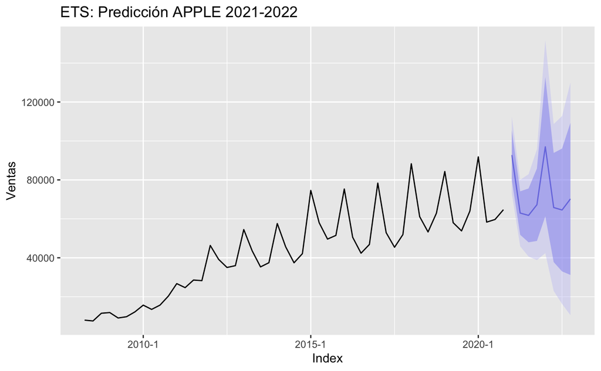

```r
#Plot
autoplot(zVentas) + geom_forecast(fventas.ets,alpha=0.4)+ggtitle("ETS: Predicción APPLE 2021-2022")
```

Aqui con los intervalos de confianza hay una polemica. Se deben calcular al 80 y 95?

Hay estudiosos q dicen reducir los intervlos de confianza a un 50 xq distorsionan mucho lo que es la realidad predictiva.

Considero q a corto plazo es bueno usar un 80 o 95 pero a LP no

# ARIMA

```r
#Select number of observation to compare forecast
cOmit=16

#Data Size
nObs=length(zVentas)

#sub_sample
oVentas <- window(zVentas,start=index(zVentas[1]),end=index(zVentas[nObs-cOmit]))

#out sample (real data to forecast performance)
pVentas <- window(zVentas,start=index(zVentas[nObs-cOmit+1]),end=index(zVentas[nObs]))
```

```r
#ARIMA MODEL Automatic
fit1=auto.arima(oVentas,lambda=0)
summary(fit1)
```

```
Series: oVentas
ARIMA(0,1,0)(0,1,0)[4]
Box Cox transformation: lambda= 0

sigma^2 estimated as 0.01472:  log likelihood=20.72
AIC=-39.45   AICc=-39.3   BIC=-38.04

Training set error measures:
                    ME     RMSE      MAE       MPE     MAPE      MASE      ACF1
Training set -764.5058 4786.405 3054.054 -1.321616 8.284962 0.4406634 0.1269135
```

Aca nos dice que no hay modelo mejor que las tasa de variacion anteriores.

Por lo tanto el ARIMA no nos aporta informacion que nos mejore la prediccion

```r
# Tasa Variacion intertrimestral
fit2=auto.arima(oVentas,lambda=0, d=1,D=0)
summary(fit2)
```

```
Series: oVentas
ARIMA(0,1,0)(1,0,0)[4]
Box Cox transformation: lambda= 0

Coefficients:
        sar1
      0.8937
s.e.  0.0605

sigma^2 estimated as 0.01443:  log likelihood=21.12
AIC=-38.24   AICc=-37.85   BIC=-35.19

Training set error measures:
                    ME     RMSE      MAE        MPE     MAPE     MASE       ACF1
Training set -423.9629 4638.302 3196.128 -0.5645792 9.201157 0.461163 0.06728995
```

Ahora hacemos analisis de residuos de lso dos modelos

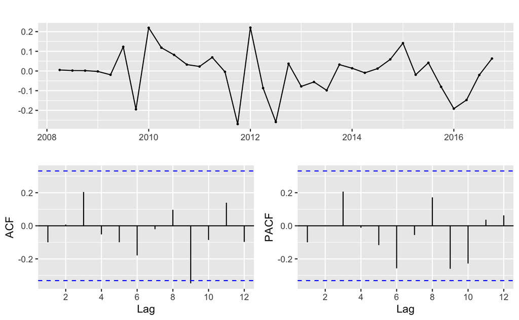

```r
#residual analysis
ggtsdisplay(fit1$residuals)
```

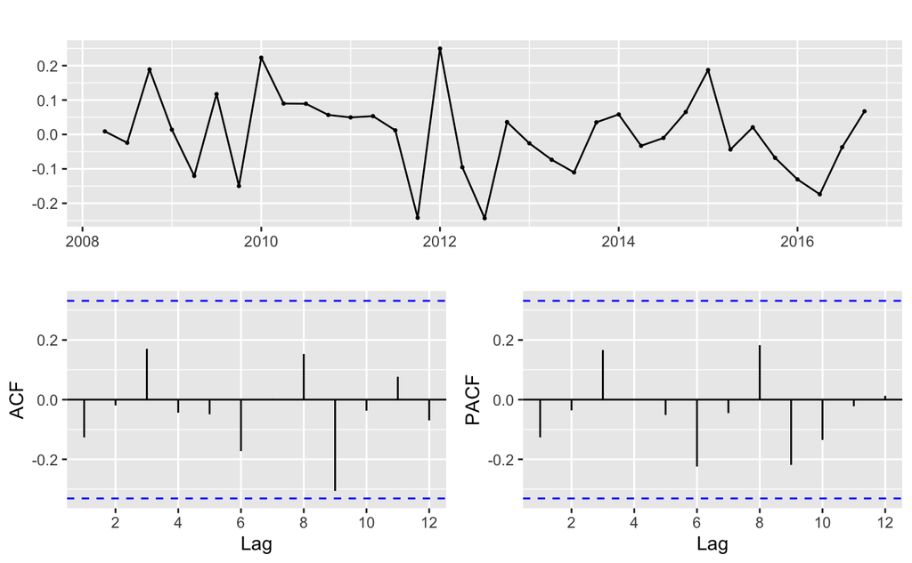

```r
ggtsdisplay(fit2$residuals)
```

Son practicamente iguales los dos modelos.

Los dos son validos desde el punto de vista de modelizacion

```r
#box-Ljung Test
#cmo el modelo estima 1 parametros fitdf=1
Box.test(fit2$residuals,lag=4, fitdf=1, type="Lj")
```

```
    Box-Ljung test

data:  fit2$residuals
X-squared = 1.8782, df = 3, p-value = 0.5981
```

```r
Box.test(fit2$residuals,lag=8, fitdf=1, type="Lj")
```

```
    Box-Ljung test

data:  fit2$residuals
X-squared = 4.4338, df = 7, p-value = 0.7287
```

```r
Box.test(fit2$residuals,lag=12, fitdf=1, type="Lj")
```

```
    Box-Ljung test

data:  fit2$residuals
X-squared = 9.7545, df = 11, p-value = 0.5526
```

Todos los residuos son ruido blanco. Entonces confirmamos que son ruido blanco

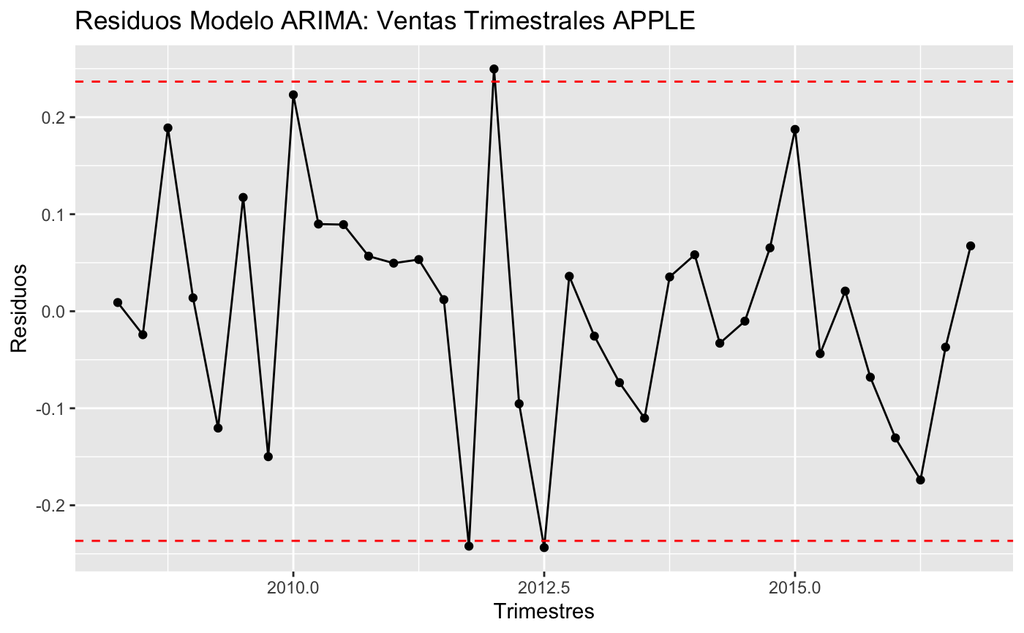

```r
#Graphic


gData=data.frame(Date=time(fit2$residuals), fit2$residuals, check.names=FALSE, row.names=NULL)
ggplot(gData, aes(x=fit2$residuals)) +
  geom_point(aes(x=Date,y=fit2$residuals))+
  geom_line(aes(x=Date,y=fit2$residuals))+
  geom_hline(yintercept = 2*sd(fit2$residuals),color="red",linetype = 2)+
  geom_hline(yintercept = -2*sd(fit2$residuals),color="red",linetype = 2)+
  ylab("Residuos")+
  ggtitle("Residuos Modelo ARIMA: Ventas Trimestrales APPLE")+
  xlab("Trimestres")
```

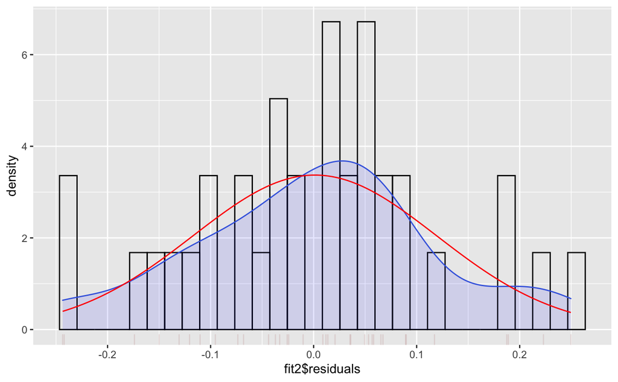

```r
ggplot(gData, aes(x=fit2$residuals)) +
  geom_histogram(aes(y = ..density..), color="black", fill=NA) + #Histogram
  geom_density(color="royalblue",fill="blue",alpha=.1)+ #Density
  geom_rug(col="darkred",alpha=.1)+ #Rug
  stat_function(fun = dnorm, colour = "red",args = list(mean = mean(fit2$residuals),sd=sd(fit2$residuals) )) #Normal Density
```

Graficamos los residuos con unas banda de mas menos 2 sigman y luego el histograma con la densidad.

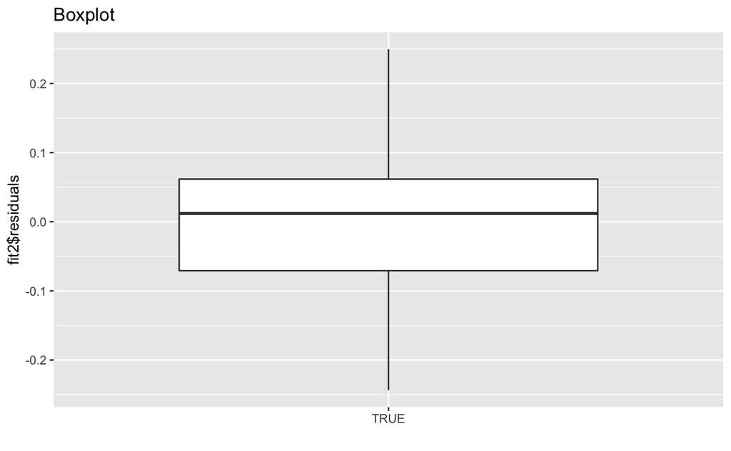

```r
#Plot boxplot
#coredata() xts to vector
ggplot(gData) + geom_boxplot(aes(x = is.numeric(fit2$residuals), y = fit2$residuals),
                             outlier.colour="red", outlier.shape=16,outlier.size=2)+
  xlab("")+ggtitle("Boxplot")
```

Aqui vemos que no sale ningun outlier en el boxplot

```r
#Jarque-Bera test (normality test)
library(moments)
jarque.test(as.numeric(coredata(fit2$residuals)))
```

```
    Jarque-Bera Normality Test

data:  as.numeric(coredata(fit2$residuals))
JB = 0.038968, p-value = 0.9807
alternative hypothesis: greater
```

La hipotesis nula de normalidad. Entonces por el p value vemos que son normales

```
Use autolayer instead of geom_forecast to add a forecast layer to your ggplot object.
```

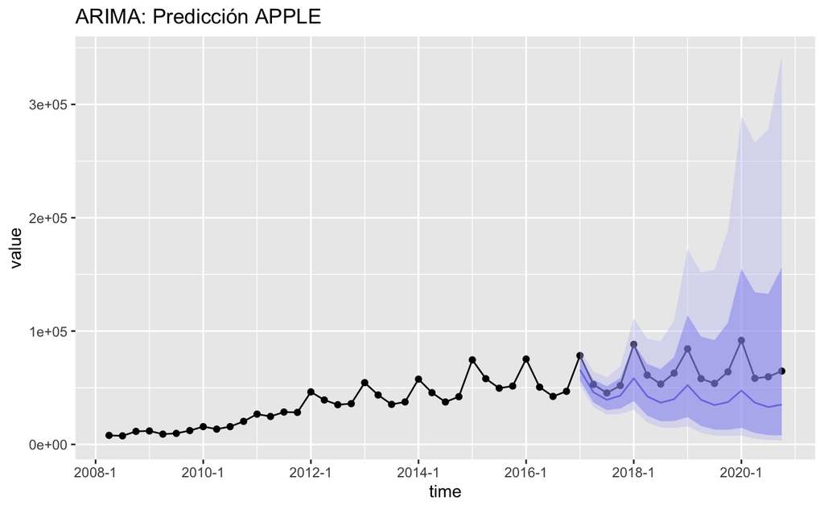

```r
#Forecast
fventas.arima=forecast(fit2,h=16)

#plot
ggplot(df_new)+geom_point(aes(x=time,y=value))+geom_line(aes(x=time,y=value))+ geom_forecast(fventas.arima,alpha=0.4)+ggtitle("ARIMA: Predicción APPLE")
```

```r
#data
fventas.arima
```

|  | Point Forecast | Lo 80 | Hi 80 | Lo 95 | Hi 95 |
| --- | --- | --- | --- | --- | --- |
| 2017 Q1 | 65809.51 | 56420.792 | 76760.55 | 52005.731 | 83277.19 |
| 2017 Q2 | 46083.78 | 37068.811 | 57291.14 | 33034.102 | 64288.55 |
| 2017 Q3 | 39343.53 | 30136.075 | 51364.14 | 26169.350 | 59149.87 |
| 2017 Q4 | 43053.60 | 31645.399 | 58574.48 | 26886.523 | 68942.08 |
| 2018 Q1 | 58328.35 | 38173.193 | 89125.27 | 30499.352 | 111549.79 |
| 2018 Q2 | 42422.17 | 25360.162 | 70963.30 | 19313.882 | 93178.61 |
| 2018 Q3 | 36831.59 | 20389.714 | 66531.88 | 14909.548 | 90986.40 |
| 2018 Q4 | 39920.43 | 20648.108 | 77180.96 | 14565.128 | 109414.82 |
| 2019 Q1 | 52365.28 | 24035.808 | 114084.90 | 15916.022 | 172286.94 |
| 2019 Q2 | 39396.80 | 16306.704 | 95182.18 | 10222.758 | 151828.65 |

[output cut: 6 more lines]

Aqui al tener logaritmo el intervalo no es simetrico. Esto quiere decir que no dal o mismo desde el inferior con el sueprrior. Por lo tanto usar logaritmo a largo plazo nos da esta ventaja.

Si fuera presidente de apple usaria este modelo para mostrarle a los accionistas.

El ARIMA no funciona. La idea fundamental es mantener las tasas de crecimiento de las ventas.

Volvemos a estimar el ETS y luego comparamos los dos

```r
## Select automatic ETS
etsfit<-ets(oVentas)
#forecast model
fventas.ets=forecast(etsfit, h=16)
#Results
summary(fventas.ets)
```

```
Forecast method: ETS(M,A,M)

Model Information:
ETS(M,A,M)

Call:
 ets(y = oVentas)

  Smoothing parameters:
    alpha = 0.493
    beta  = 0.493
    gamma = 0.507

  Initial states:
    l = 7125.3462
    b = 1485.7975
    s = 1.1511 1.1163 0.8322 0.9004

  sigma:  0.1222

     AIC     AICc      BIC
703.9538 711.1538 717.9519

Error measures:
                  ME     RMSE      MAE       MPE     MAPE      MASE      ACF1
Training set -41.934 4120.155 2883.262 -0.297759 8.677434 0.4160202 0.1438481

Forecasts:
```

|  | Point Forecast | Lo 80 | Hi 80 | Lo 95 | Hi 95 |
| --- | --- | --- | --- | --- | --- |
| 2017 Q1 | 69439.83 | 58568.387 | 80311.27 | 52813.394 | 86066.26 |
| 2017 Q2 | 53347.98 | 41773.016 | 64922.95 | 35645.598 | 71050.37 |
| 2017 Q3 | 48972.04 | 33884.613 | 64059.47 | 25897.811 | 72046.27 |
| 2017 Q4 | 54176.09 | 31475.035 | 76877.14 | 19457.824 | 88894.35 |
| 2018 Q1 | 80540.07 | 32680.293 | 128399.85 | 7344.857 | 153735.28 |
| 2018 Q2 | 61619.03 | 17211.212 | 106026.85 | -6296.866 | 129534.93 |
| 2018 Q3 | 56344.41 | 7869.773 | 104819.05 | -17791.151 | 130479.97 |
| 2018 Q4 | 62103.80 | -718.363 | 124925.97 | -33974.410 | 158182.02 |
| 2019 Q1 | 92883.46 | -19130.793 | 204897.71 | -78427.555 | 264194.47 |
| 2019 Q2 | 70840.35 | -26312.837 | 167993.53 | -77742.626 | 219423.32 |

[output cut: 6 more lines]

```
Use autolayer instead of geom_forecast to add a forecast layer to your ggplot object.Ignoring unknown parameters: plot.confUse autolayer instead of geom_forecast to add a forecast layer to your ggplot object.Ignoring unknown parameters: plot.conf
```

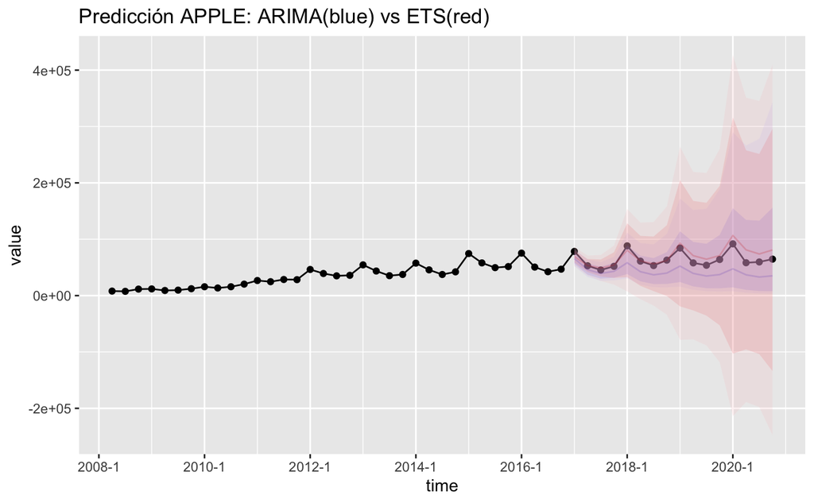

```r
#Plot
ggplot(df_new)+geom_point(aes(x=time,y=value))+
  geom_line(aes(x=time,y=value))+
  geom_forecast(fventas.arima,color="blue",alpha=0.183, plot.conf = FALSE)+
  geom_forecast(fventas.ets,color="red", alpha=0.183,plot.conf = FALSE)+
  ggtitle("Predicción APPLE: ARIMA(blue) vs ETS(red)")
```

```r
cbind(fventas.arima$mean,fventas.ets$mean)
```

```
        fventas.arima$mean fventas.ets$mean
2017 Q1           65809.51         69439.83
2017 Q2           46083.78         53347.98
2017 Q3           39343.53         48972.04
2017 Q4           43053.60         54176.09
2018 Q1           58328.35         80540.07
2018 Q2           42422.17         61619.03
2018 Q3           36831.59         56344.41
2018 Q4           39920.43         62103.80
2019 Q1           52365.28         92883.46
2019 Q2           39396.80         70840.35
2019 Q3           34722.76         64584.99
2019 Q4           37313.86         70987.74
2020 Q1           47554.04        106658.80
2020 Q2           36876.15         81153.07
2020 Q3           32940.55         73819.99
2020 Q4           35128.79         80964.03
```

```
Use autolayer instead of geom_forecast to add a forecast layer to your ggplot object.Use autolayer instead of geom_forecast to add a forecast layer to your ggplot object.
```

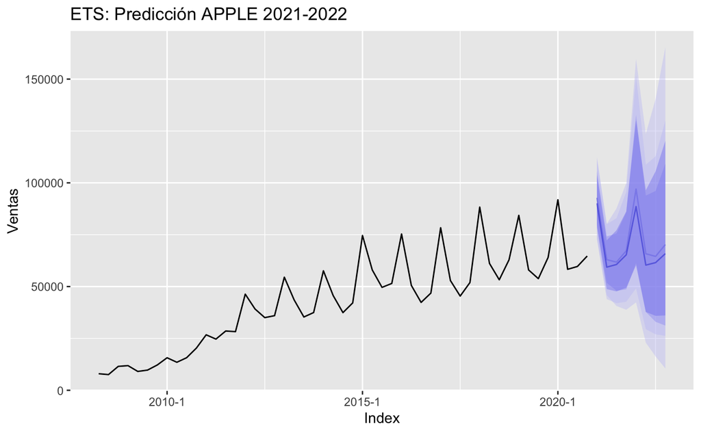

```r
#Forecast out of the sample
cOmit=0

#Data Size
nObs=length(zVentas)

#sub_sample
oVentas <- window(zVentas,start=index(zVentas[1]),end=index(zVentas[nObs-cOmit]))
## Select automatic ETS
etsfit<-ets(oVentas)
#forecast model
fventas.ets=forecast(etsfit)

## ARIMA
fit2=auto.arima(oVentas,lambda=0, d=1,D=0)
fventas.arima=forecast(fit2)

#Plot
autoplot(zVentas) + geom_forecast(fventas.ets,alpha=0.4)+ggtitle("ETS: Predicción APPLE 2021-2022")+
  geom_forecast(fventas.arima,alpha=0.4)+ggtitle("ETS: Predicción APPLE 2021-2022")
```

Fuera de la muestra ya no hay tanta diferencia entre ETS y ARIMA. A corto plazo son practicamente iguales, cambian luego en el segundo.

El ARIMA no capta bien el componente estacional mientra que el ETS si.

Ahora nos introducimos al paquete tsibble. Con tidyverse crearon los datos tsibble que son data frames de series temporales. que se usan para los modelos.

La diferencia forecast con el AutoArima solo nos permite estimar una serie temporal. Ahora con esto podemos estimar un conjunto de series temporales.

Con fagre podemos estimar las series de 50 sucursales lo hacemos todo de una.

Fagre es el mismo que fagre. tsibble nos permite usar dplyr. # tsibble https://tidyverts.org https://tsibble.tidyverts.org

```r
library(tsibble)
tsVentas <- tsibble(ventas=rawVentas,trimestre=yearquarter(rawDate),index=trimestre)

str(tsVentas)
```

```
tsibble [51 × 2] (S3: tbl_ts/tbl_df/tbl/data.frame)
 $ ventas   : int [1:51] 7980 7561 11520 11880 9084 9734 12207 15683 13499 15700 ...
 $ trimestre: qtr [1:51] 2008 Q2, 2008 Q3, 2008 Q4, 2009 Q1, 2009 Q2, 2009 Q3, 2009 Q4, 2010 Q1, 2010 Q2, 2010 Q3,...
   ..@ fiscal_start: num 1
 - attr(*, "key")= tibble [1 × 1] (S3: tbl_df/tbl/data.frame)
  ..$ .rows: list<int> [1:1]
  .. ..$ : int [1:51] 1 2 3 4 5 6 7 8 9 10 ...
  .. ..@ ptype: int(0)
 - attr(*, "index")= chr "trimestre"
  ..- attr(*, "ordered")= logi TRUE
 - attr(*, "index2")= chr "trimestre"
 - attr(*, "interval")= interval [1:1] 1Q
  ..@ .regular: logi TRUE
```

```r
tsVentas
```

| ventas | trimestre |
| --- | --- |
| 7980 | 2008 Q2 |
| 7561 | 2008 Q3 |
| 11520 | 2008 Q4 |
| 11880 | 2009 Q1 |
| 9084 | 2009 Q2 |
| 9734 | 2009 Q3 |
| 12207 | 2009 Q4 |
| 15683 | 2010 Q1 |
| 13499 | 2010 Q2 |
| 15700 | 2010 Q3 |

[output cut: 41 more lines]

La estructura de esto nos dice que es una clase S3 que es un objeto parte de dataframe y constriuye una tabla data frame, una table tsbile y una tabla comun. Es decir funcionara cualquiera de los tres objetos.

La series ventas y trimestre y todo el resto de indicadores. El intervalo abajo nos dice que es trimestral.

Ventas son enteros y trimetres es S3 de tipo trimestral.

Ahora podemos trabajar directamente con ggplot 2

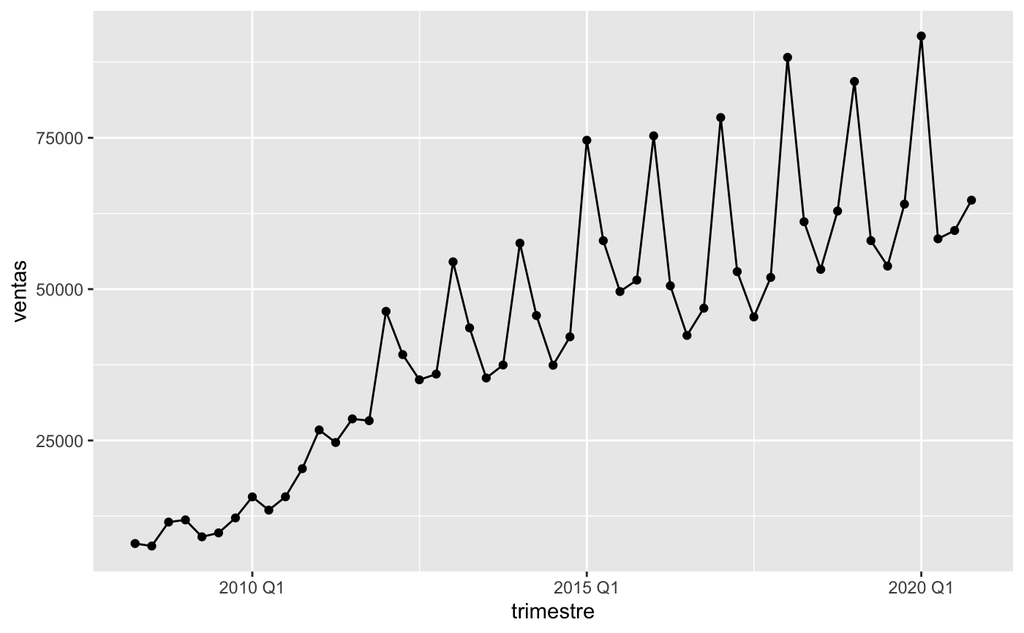

```r
tsVentas %>% ggplot(aes(x=trimestre,y=ventas))+geom_line()+geom_point()
```

Ahora entiende perfectamente los datos # Fable

Es el forecast utulizado para este tipo de objeto

```r
library(fable)
library(feasts)
otsVentas <- tsVentas %>%
  filter_index(~"2016 Q4") #tiene un filtro como dplyr que significa hasta esta fecha. No se dice omite tanto. Aca solo ponemos la fecha. Coge desde el origen hasta q4 de 2016.


tsfit <- otsVentas %>% model(ets=ETS(ventas),arima=ARIMA(log(ventas))) #guarda los datos en tsfir. Estima un modelo automatico ETS a ventas y luego un ARIMA en log a ventas

tsfit
```

[output not shown]

```r
tsfit %>% dplyr::select(ets) %>% report() #coge el resultado de ets y haz el report
```

```
Series: ventas
Model: ETS(M,A,M)
  Smoothing parameters:
    alpha = 0.4930222
    beta  = 0.4930195
    gamma = 0.5069777

  Initial states:
        l        b       s1       s2        s3        s4
 7125.346 1485.798 1.151052 1.116303 0.8322492 0.9003961

  sigma^2:  0.0149

     AIC     AICc      BIC
703.9538 711.1538 717.9519
```

```r
tsfit %>% dplyr::select(arima) %>% report() #
```

```
Series: ventas
Model: ARIMA(0,1,0)(0,1,0)[4]
Transformation: log(.x)

sigma^2 estimated as 0.01472:  log likelihood=20.72
AIC=-39.45   AICc=-39.3   BIC=-38.04
```

```r
tsfit %>% accuracy() #de los dos modelos dame el accuracy
```

| .model | .type | ME | RMSE | MAE | MPE | MAPE | MASE | ACF1 |
| --- | --- | --- | --- | --- | --- | --- | --- | --- |
| ets | Training | -41.9340 | 4120.155 | 2883.262 | -0.297759 | 8.677434 | 0.4160202 | 0.1438481 |
| arima | Training | -764.5058 | 4786.405 | 3054.054 | -1.321616 | 8.284962 | 0.4406634 | 0.1269135 |

```r
tsfc <- tsfit %>%
  forecast(h = "1 years") #de los dos modelos hazme la prediccion a un an1o y guardalo en tsfc
tsfc
```

| .model | trimestre | ventas | .mean |
| --- | --- | --- | --- |
| ets | 2017 Q1 |  | 69439.83 |
| ets | 2017 Q2 |  | 53347.98 |
| ets | 2017 Q3 |  | 48972.04 |
| ets | 2017 Q4 |  | 54176.09 |
| arima | 2017 Q1 |  | 69028.88 |
| arima | 2017 Q2 |  | 46670.29 |
| arima | 2017 Q3 |  | 39385.25 |
| arima | 2017 Q4 |  | 43877.58 |

```r
tsfc %>% accuracy(tsVentas) #hazlo con las ventas reales al accuracy
```

| .model | .type | ME | RMSE | MAE | MPE | MAPE | MASE | ACF1 |
| --- | --- | --- | --- | --- | --- | --- | --- | --- |
| arima | Test | 7408.0031 | 7531.958 | 7408.003 | 13.1130515 | 13.113052 | 1.0688864 | -0.2066043 |
| ets | Test | 664.5142 | 4932.550 | 3791.071 | -0.4092885 | 6.095988 | 0.5470063 | 0.0814554 |

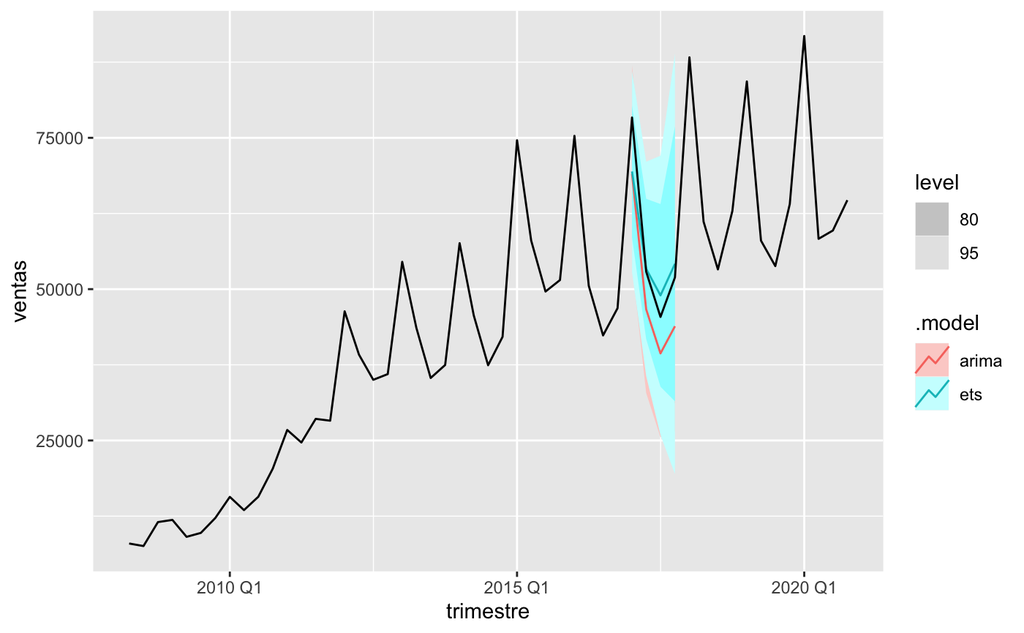

```r
tsfc %>% autoplot(tsVentas) #replicame las ventas
```

En tsfit tiene dos columnas con ETS y el ARIMA (nombre q le pusimos)

Luego tenemos los modelos con sus errores.

En el test vemos el comportamiento en los cuatro trimestre de 2017.

# Cross Validation

```r
library(dplyr)
apple_tr <- tsVentas %>%
  dplyr::slice(1:(n()-8)) %>%
  stretch_tsibble(.init = 20, .step = 1)

fc <- apple_tr %>%
  model(ETS(ventas),ARIMA(log(ventas))) %>%
  forecast(h = 8) %>%
  group_by(.id,.model) %>%
  mutate(h = row_number()) %>%
  ungroup()
```

```
Having 3 or more differencing operations is not recommended. Please consider reducing the total number of differences.
```

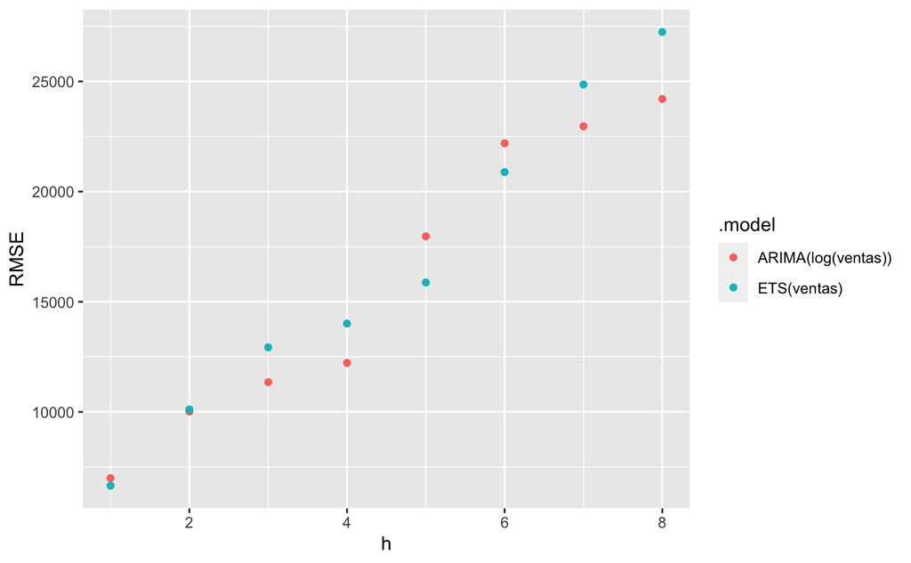

```r
fc %>%
  accuracy(tsVentas, by = c("h", ".model")) %>%
  ggplot(aes(x = h, y = RMSE,color=.model)) +
  geom_point()
```

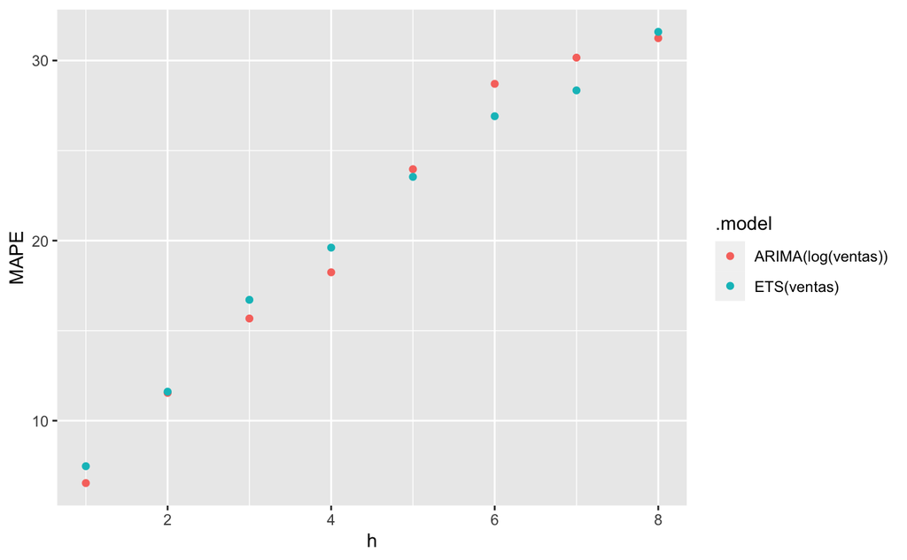

```r
fc %>%
  accuracy(tsVentas, by = c("h", ".model")) %>%
  ggplot(aes(x = h, y = MAPE,color=.model)) +
  geom_point()
```

```r
NA
NA
NA
```

Nos dice que a corto plazo el error es muy pequeno.

Si es a 4 podemos ver que se comporta mejor el ARIMA. En periodos anteriores da igual.